# R Notebook

```r
wisc_df <- read.csv("C:/Users/valle/Documents/GitHub/AADC-R-Projects/4.1-CancerProject/data/WisconsinCancer.csv")


str(wisc_df)
```

```
'data.frame':   569 obs. of  33 variables:
 $ id                     : int  842302 842517 84300903 84348301 84358402 843786 844359 84458202 844981 84501001 ...
 $ diagnosis              : chr  "M" "M" "M" "M" ...
 $ radius_mean            : num  18 20.6 19.7 11.4 20.3 ...
 $ texture_mean           : num  10.4 17.8 21.2 20.4 14.3 ...
 $ perimeter_mean         : num  122.8 132.9 130 77.6 135.1 ...
 $ area_mean              : num  1001 1326 1203 386 1297 ...
 $ smoothness_mean        : num  0.1184 0.0847 0.1096 0.1425 0.1003 ...
 $ compactness_mean       : num  0.2776 0.0786 0.1599 0.2839 0.1328 ...
 $ concavity_mean         : num  0.3001 0.0869 0.1974 0.2414 0.198 ...
 $ concave.points_mean    : num  0.1471 0.0702 0.1279 0.1052 0.1043 ...
 $ symmetry_mean          : num  0.242 0.181 0.207 0.26 0.181 ...
 $ fractal_dimension_mean : num  0.0787 0.0567 0.06 0.0974 0.0588 ...
 $ radius_se              : num  1.095 0.543 0.746 0.496 0.757 ...
 $ texture_se             : num  0.905 0.734 0.787 1.156 0.781 ...
```

[output cut: 19 more lines]

```r
head(wisc_df)
```

|  | id | diagnosis | radius_mean | texture_mean | perimeter_mean | area_mean | smoothness_mean | compactness_mean | concavity_mean | concave.points_mean | symmetry_mean | fractal_dimension_mean | radius_se | texture_se | perimeter_se | area_se | smoothness_se | compactness_se | concavity_se | concave.points_se | symmetry_se | fractal_dimension_se | radius_worst | texture_worst | perimeter_worst | area_worst | smoothness_worst | compactness_worst | concavity_worst | … |
| --- | --- | --- | --- | --- | --- | --- | --- | --- | --- | --- | --- | --- | --- | --- | --- | --- | --- | --- | --- | --- | --- | --- | --- | --- | --- | --- | --- | --- | --- | --- |
| 1 | 842302 | M | 17.99 | 10.38 | 122.80 | 1001.0 | 0.11840 | 0.27760 | 0.3001 | 0.14710 | 0.2419 | 0.07871 | 1.0950 | 0.9053 | 8.589 | 153.40 | 0.006399 | 0.04904 | 0.05373 | 0.01587 | 0.03003 | 0.006193 | 25.38 | 17.33 | 184.60 | 2019.0 | 0.1622 | 0.6656 | 0.7119 | … |
| 2 | 842517 | M | 20.57 | 17.77 | 132.90 | 1326.0 | 0.08474 | 0.07864 | 0.0869 | 0.07017 | 0.1812 | 0.05667 | 0.5435 | 0.7339 | 3.398 | 74.08 | 0.005225 | 0.01308 | 0.01860 | 0.01340 | 0.01389 | 0.003532 | 24.99 | 23.41 | 158.80 | 1956.0 | 0.1238 | 0.1866 | 0.2416 | … |
| 3 | 84300903 | M | 19.69 | 21.25 | 130.00 | 1203.0 | 0.10960 | 0.15990 | 0.1974 | 0.12790 | 0.2069 | 0.05999 | 0.7456 | 0.7869 | 4.585 | 94.03 | 0.006150 | 0.04006 | 0.03832 | 0.02058 | 0.02250 | 0.004571 | 23.57 | 25.53 | 152.50 | 1709.0 | 0.1444 | 0.4245 | 0.4504 | … |
| 4 | 84348301 | M | 11.42 | 20.38 | 77.58 | 386.1 | 0.14250 | 0.28390 | 0.2414 | 0.10520 | 0.2597 | 0.09744 | 0.4956 | 1.1560 | 3.445 | 27.23 | 0.009110 | 0.07458 | 0.05661 | 0.01867 | 0.05963 | 0.009208 | 14.91 | 26.50 | 98.87 | 567.7 | 0.2098 | 0.8663 | 0.6869 | … |
| 5 | 84358402 | M | 20.29 | 14.34 | 135.10 | 1297.0 | 0.10030 | 0.13280 | 0.1980 | 0.10430 | 0.1809 | 0.05883 | 0.7572 | 0.7813 | 5.438 | 94.44 | 0.011490 | 0.02461 | 0.05688 | 0.01885 | 0.01756 | 0.005115 | 22.54 | 16.67 | 152.20 | 1575.0 | 0.1374 | 0.2050 | 0.4000 | … |
| 6 | 843786 | M | 12.45 | 15.70 | 82.57 | 477.1 | 0.12780 | 0.17000 | 0.1578 | 0.08089 | 0.2087 | 0.07613 | 0.3345 | 0.8902 | 2.217 | 27.19 | 0.007510 | 0.03345 | 0.03672 | 0.01137 | 0.02165 | 0.005082 | 15.47 | 23.75 | 103.40 | 741.6 | 0.1791 | 0.5249 | 0.5355 | … |

```r
tail(wisc_df)
```

|  | id | diagnosis | radius_mean | texture_mean | perimeter_mean | area_mean | smoothness_mean | compactness_mean | concavity_mean | concave.points_mean | symmetry_mean | fractal_dimension_mean | radius_se | texture_se | perimeter_se | area_se | smoothness_se | compactness_se | concavity_se | concave.points_se | symmetry_se | fractal_dimension_se | radius_worst | texture_worst | perimeter_worst | area_worst | smoothness_worst | compactness_worst | concavity_worst | … |
| --- | --- | --- | --- | --- | --- | --- | --- | --- | --- | --- | --- | --- | --- | --- | --- | --- | --- | --- | --- | --- | --- | --- | --- | --- | --- | --- | --- | --- | --- | --- |
| 564 | 926125 | M | 20.92 | 25.09 | 143.00 | 1347.0 | 0.10990 | 0.22360 | 0.31740 | 0.14740 | 0.2149 | 0.06879 | 0.9622 | 1.026 | 8.758 | 118.80 | 0.006399 | 0.04310 | 0.07845 | 0.02624 | 0.02057 | 0.006213 | 24.290 | 29.41 | 179.10 | 1819.0 | 0.14070 | 0.41860 | 0.6599 | … |
| 565 | 926424 | M | 21.56 | 22.39 | 142.00 | 1479.0 | 0.11100 | 0.11590 | 0.24390 | 0.13890 | 0.1726 | 0.05623 | 1.1760 | 1.256 | 7.673 | 158.70 | 0.010300 | 0.02891 | 0.05198 | 0.02454 | 0.01114 | 0.004239 | 25.450 | 26.40 | 166.10 | 2027.0 | 0.14100 | 0.21130 | 0.4107 | … |
| 566 | 926682 | M | 20.13 | 28.25 | 131.20 | 1261.0 | 0.09780 | 0.10340 | 0.14400 | 0.09791 | 0.1752 | 0.05533 | 0.7655 | 2.463 | 5.203 | 99.04 | 0.005769 | 0.02423 | 0.03950 | 0.01678 | 0.01898 | 0.002498 | 23.690 | 38.25 | 155.00 | 1731.0 | 0.11660 | 0.19220 | 0.3215 | … |
| 567 | 926954 | M | 16.60 | 28.08 | 108.30 | 858.1 | 0.08455 | 0.10230 | 0.09251 | 0.05302 | 0.1590 | 0.05648 | 0.4564 | 1.075 | 3.425 | 48.55 | 0.005903 | 0.03731 | 0.04730 | 0.01557 | 0.01318 | 0.003892 | 18.980 | 34.12 | 126.70 | 1124.0 | 0.11390 | 0.30940 | 0.3403 | … |
| 568 | 927241 | M | 20.60 | 29.33 | 140.10 | 1265.0 | 0.11780 | 0.27700 | 0.35140 | 0.15200 | 0.2397 | 0.07016 | 0.7260 | 1.595 | 5.772 | 86.22 | 0.006522 | 0.06158 | 0.07117 | 0.01664 | 0.02324 | 0.006185 | 25.740 | 39.42 | 184.60 | 1821.0 | 0.16500 | 0.86810 | 0.9387 | … |
| 569 | 92751 | B | 7.76 | 24.54 | 47.92 | 181.0 | 0.05263 | 0.04362 | 0.00000 | 0.00000 | 0.1587 | 0.05884 | 0.3857 | 1.428 | 2.548 | 19.15 | 0.007189 | 0.00466 | 0.00000 | 0.00000 | 0.02676 | 0.002783 | 9.456 | 30.37 | 59.16 | 268.6 | 0.08996 | 0.06444 | 0.0000 | … |

```r
dim(wisc_df)
```

```
[1] 569  33
```

Nos hemos dado cuenta que tenemos que trabajar solo con las columnas desde la tercera en adelante. El clustering solo tiene sentido con datos numéricos

```r
#Construimos una matriz con la parte numérica del datafame
wisc_data <- as.matrix(wisc_df[3:32])

#Le ponemos los ids como nombre a las filas de la matriz
rownames(wisc_data)<- wisc_df$id
summary(wisc_data)
```

```
  radius_mean      texture_mean   perimeter_mean     area_mean      smoothness_mean
 Min.   : 6.981   Min.   : 9.71   Min.   : 43.79   Min.   : 143.5   Min.   :0.05263
 1st Qu.:11.700   1st Qu.:16.17   1st Qu.: 75.17   1st Qu.: 420.3   1st Qu.:0.08637
 Median :13.370   Median :18.84   Median : 86.24   Median : 551.1   Median :0.09587
 Mean   :14.127   Mean   :19.29   Mean   : 91.97   Mean   : 654.9   Mean   :0.09636
 3rd Qu.:15.780   3rd Qu.:21.80   3rd Qu.:104.10   3rd Qu.: 782.7   3rd Qu.:0.10530
 Max.   :28.110   Max.   :39.28   Max.   :188.50   Max.   :2501.0   Max.   :0.16340
 compactness_mean  concavity_mean    concave.points_mean symmetry_mean
 Min.   :0.01938   Min.   :0.00000   Min.   :0.00000     Min.   :0.1060
 1st Qu.:0.06492   1st Qu.:0.02956   1st Qu.:0.02031     1st Qu.:0.1619
 Median :0.09263   Median :0.06154   Median :0.03350     Median :0.1792
 Mean   :0.10434   Mean   :0.08880   Mean   :0.04892     Mean   :0.1812
 3rd Qu.:0.13040   3rd Qu.:0.13070   3rd Qu.:0.07400     3rd Qu.:0.1957
 Max.   :0.34540   Max.   :0.42680   Max.   :0.20120     Max.   :0.3040
 fractal_dimension_mean   radius_se        texture_se      perimeter_se       area_se
 Min.   :0.04996        Min.   :0.1115   Min.   :0.3602   Min.   : 0.757   Min.   :  6.802
 1st Qu.:0.05770        1st Qu.:0.2324   1st Qu.:0.8339   1st Qu.: 1.606   1st Qu.: 17.850
 Median :0.06154        Median :0.3242   Median :1.1080   Median : 2.287   Median : 24.530
 Mean   :0.06280        Mean   :0.4052   Mean   :1.2169   Mean   : 2.866   Mean   : 40.337
 3rd Qu.:0.06612        3rd Qu.:0.4789   3rd Qu.:1.4740   3rd Qu.: 3.357   3rd Qu.: 45.190
 Max.   :0.09744        Max.   :2.8730   Max.   :4.8850   Max.   :21.980   Max.   :542.200
 smoothness_se      compactness_se      concavity_se     concave.points_se   symmetry_se
 Min.   :0.001713   Min.   :0.002252   Min.   :0.00000   Min.   :0.000000   Min.   :0.007882
 1st Qu.:0.005169   1st Qu.:0.013080   1st Qu.:0.01509   1st Qu.:0.007638   1st Qu.:0.015160
 Median :0.006380   Median :0.020450   Median :0.02589   Median :0.010930   Median :0.018730
 Mean   :0.007041   Mean   :0.025478   Mean   :0.03189   Mean   :0.011796   Mean   :0.020542
 3rd Qu.:0.008146   3rd Qu.:0.032450   3rd Qu.:0.04205   3rd Qu.:0.014710   3rd Qu.:0.023480
 Max.   :0.031130   Max.   :0.135400   Max.   :0.39600   Max.   :0.052790   Max.   :0.078950
 fractal_dimension_se  radius_worst   texture_worst   perimeter_worst    area_worst
 Min.   :0.0008948    Min.   : 7.93   Min.   :12.02   Min.   : 50.41   Min.   : 185.2
 1st Qu.:0.0022480    1st Qu.:13.01   1st Qu.:21.08   1st Qu.: 84.11   1st Qu.: 515.3
 Median :0.0031870    Median :14.97   Median :25.41   Median : 97.66   Median : 686.5
 Mean   :0.0037949    Mean   :16.27   Mean   :25.68   Mean   :107.26   Mean   : 880.6
 3rd Qu.:0.0045580    3rd Qu.:18.79   3rd Qu.:29.72   3rd Qu.:125.40   3rd Qu.:1084.0
 Max.   :0.0298400    Max.   :36.04   Max.   :49.54   Max.   :251.20   Max.   :4254.0
 smoothness_worst  compactness_worst concavity_worst  concave.points_worst symmetry_worst
 Min.   :0.07117   Min.   :0.02729   Min.   :0.0000   Min.   :0.00000      Min.   :0.1565
 1st Qu.:0.11660   1st Qu.:0.14720   1st Qu.:0.1145   1st Qu.:0.06493      1st Qu.:0.2504
 Median :0.13130   Median :0.21190   Median :0.2267   Median :0.09993      Median :0.2822
 Mean   :0.13237   Mean   :0.25427   Mean   :0.2722   Mean   :0.11461      Mean   :0.2901
 3rd Qu.:0.14600   3rd Qu.:0.33910   3rd Qu.:0.3829   3rd Qu.:0.16140      3rd Qu.:0.3179
 Max.   :0.22260   Max.   :1.05800   Max.   :1.2520   Max.   :0.29100      Max.   :0.6638
 fractal_dimension_worst
 Min.   :0.05504
 1st Qu.:0.07146
 Median :0.08004
 Mean   :0.08395
 3rd Qu.:0.09208
 Max.   :0.20750
```

```r
head(wisc_data)
```

```
         radius_mean texture_mean perimeter_mean area_mean smoothness_mean compactness_mean
842302         17.99        10.38         122.80    1001.0         0.11840          0.27760
842517         20.57        17.77         132.90    1326.0         0.08474          0.07864
84300903       19.69        21.25         130.00    1203.0         0.10960          0.15990
84348301       11.42        20.38          77.58     386.1         0.14250          0.28390
84358402       20.29        14.34         135.10    1297.0         0.10030          0.13280
843786         12.45        15.70          82.57     477.1         0.12780          0.17000
         concavity_mean concave.points_mean symmetry_mean fractal_dimension_mean radius_se
842302           0.3001             0.14710        0.2419                0.07871    1.0950
842517           0.0869             0.07017        0.1812                0.05667    0.5435
84300903         0.1974             0.12790        0.2069                0.05999    0.7456
84348301         0.2414             0.10520        0.2597                0.09744    0.4956
84358402         0.1980             0.10430        0.1809                0.05883    0.7572
843786           0.1578             0.08089        0.2087                0.07613    0.3345
         texture_se perimeter_se area_se smoothness_se compactness_se concavity_se
```

[output cut: 27 more lines]

Nos damos cuenta que tenemos que escalar los datos para que todas las variables(las columnas de la matriz) tengan un mismo rango.

```r
wisc_data_escalados <- scale(wisc_data)
summary(wisc_data_escalados)
```

```
  radius_mean       texture_mean     perimeter_mean      area_mean       smoothness_mean
 Min.   :-2.0279   Min.   :-2.2273   Min.   :-1.9828   Min.   :-1.4532   Min.   :-3.10935
 1st Qu.:-0.6888   1st Qu.:-0.7253   1st Qu.:-0.6913   1st Qu.:-0.6666   1st Qu.:-0.71034
 Median :-0.2149   Median :-0.1045   Median :-0.2358   Median :-0.2949   Median :-0.03486
 Mean   : 0.0000   Mean   : 0.0000   Mean   : 0.0000   Mean   : 0.0000   Mean   : 0.00000
 3rd Qu.: 0.4690   3rd Qu.: 0.5837   3rd Qu.: 0.4992   3rd Qu.: 0.3632   3rd Qu.: 0.63564
 Max.   : 3.9678   Max.   : 4.6478   Max.   : 3.9726   Max.   : 5.2459   Max.   : 4.76672
 compactness_mean  concavity_mean    concave.points_mean symmetry_mean
 Min.   :-1.6087   Min.   :-1.1139   Min.   :-1.2607     Min.   :-2.74171
 1st Qu.:-0.7464   1st Qu.:-0.7431   1st Qu.:-0.7373     1st Qu.:-0.70262
 Median :-0.2217   Median :-0.3419   Median :-0.3974     Median :-0.07156
 Mean   : 0.0000   Mean   : 0.0000   Mean   : 0.0000     Mean   : 0.00000
 3rd Qu.: 0.4934   3rd Qu.: 0.5256   3rd Qu.: 0.6464     3rd Qu.: 0.53031
 Max.   : 4.5644   Max.   : 4.2399   Max.   : 3.9245     Max.   : 4.48081
 fractal_dimension_mean   radius_se         texture_se       perimeter_se
 Min.   :-1.8183        Min.   :-1.0590   Min.   :-1.5529   Min.   :-1.0431
 1st Qu.:-0.7220        1st Qu.:-0.6230   1st Qu.:-0.6942   1st Qu.:-0.6232
 Median :-0.1781        Median :-0.2920   Median :-0.1973   Median :-0.2864
 Mean   : 0.0000        Mean   : 0.0000   Mean   : 0.0000   Mean   : 0.0000
 3rd Qu.: 0.4706        3rd Qu.: 0.2659   3rd Qu.: 0.4661   3rd Qu.: 0.2428
 Max.   : 4.9066        Max.   : 8.8991   Max.   : 6.6494   Max.   : 9.4537
    area_se        smoothness_se     compactness_se     concavity_se     concave.points_se
 Min.   :-0.7372   Min.   :-1.7745   Min.   :-1.2970   Min.   :-1.0566   Min.   :-1.9118
 1st Qu.:-0.4943   1st Qu.:-0.6235   1st Qu.:-0.6923   1st Qu.:-0.5567   1st Qu.:-0.6739
 Median :-0.3475   Median :-0.2201   Median :-0.2808   Median :-0.1989   Median :-0.1404
 Mean   : 0.0000   Mean   : 0.0000   Mean   : 0.0000   Mean   : 0.0000   Mean   : 0.0000
 3rd Qu.: 0.1067   3rd Qu.: 0.3680   3rd Qu.: 0.3893   3rd Qu.: 0.3365   3rd Qu.: 0.4722
 Max.   :11.0321   Max.   : 8.0229   Max.   : 6.1381   Max.   :12.0621   Max.   : 6.6438
  symmetry_se      fractal_dimension_se  radius_worst     texture_worst      perimeter_worst
 Min.   :-1.5315   Min.   :-1.0960      Min.   :-1.7254   Min.   :-2.22204   Min.   :-1.6919
 1st Qu.:-0.6511   1st Qu.:-0.5846      1st Qu.:-0.6743   1st Qu.:-0.74797   1st Qu.:-0.6890
 Median :-0.2192   Median :-0.2297      Median :-0.2688   Median :-0.04348   Median :-0.2857
 Mean   : 0.0000   Mean   : 0.0000      Mean   : 0.0000   Mean   : 0.00000   Mean   : 0.0000
 3rd Qu.: 0.3554   3rd Qu.: 0.2884      3rd Qu.: 0.5216   3rd Qu.: 0.65776   3rd Qu.: 0.5398
 Max.   : 7.0657   Max.   : 9.8429      Max.   : 4.0906   Max.   : 3.88249   Max.   : 4.2836
   area_worst      smoothness_worst  compactness_worst concavity_worst   concave.points_worst
 Min.   :-1.2213   Min.   :-2.6803   Min.   :-1.4426   Min.   :-1.3047   Min.   :-1.7435
 1st Qu.:-0.6416   1st Qu.:-0.6906   1st Qu.:-0.6805   1st Qu.:-0.7558   1st Qu.:-0.7557
 Median :-0.3409   Median :-0.0468   Median :-0.2693   Median :-0.2180   Median :-0.2233
 Mean   : 0.0000   Mean   : 0.0000   Mean   : 0.0000   Mean   : 0.0000   Mean   : 0.0000
 3rd Qu.: 0.3573   3rd Qu.: 0.5970   3rd Qu.: 0.5392   3rd Qu.: 0.5307   3rd Qu.: 0.7119
 Max.   : 5.9250   Max.   : 3.9519   Max.   : 5.1084   Max.   : 4.6965   Max.   : 2.6835
 symmetry_worst    fractal_dimension_worst
 Min.   :-2.1591   Min.   :-1.6004
 1st Qu.:-0.6413   1st Qu.:-0.6913
 Median :-0.1273   Median :-0.2163
 Mean   : 0.0000   Mean   : 0.0000
 3rd Qu.: 0.4497   3rd Qu.: 0.4504
 Max.   : 6.0407   Max.   : 6.8408
```

```r
dim(wisc_data_escalados)
```

```
[1] 569  30
```

## Análisis de Componentes Principales o PCA

Aplicamos un PCA

```r
wisc_pca <- prcomp(wisc_data_escalados, scale = TRUE)
summary(wisc_pca)
```

```
Importance of components:
                          PC1    PC2     PC3     PC4     PC5     PC6     PC7     PC8    PC9
Standard deviation     3.6444 2.3857 1.67867 1.40735 1.28403 1.09880 0.82172 0.69037 0.6457
Proportion of Variance 0.4427 0.1897 0.09393 0.06602 0.05496 0.04025 0.02251 0.01589 0.0139
Cumulative Proportion  0.4427 0.6324 0.72636 0.79239 0.84734 0.88759 0.91010 0.92598 0.9399
                          PC10   PC11    PC12    PC13    PC14    PC15    PC16    PC17    PC18
Standard deviation     0.59219 0.5421 0.51104 0.49128 0.39624 0.30681 0.28260 0.24372 0.22939
Proportion of Variance 0.01169 0.0098 0.00871 0.00805 0.00523 0.00314 0.00266 0.00198 0.00175
Cumulative Proportion  0.95157 0.9614 0.97007 0.97812 0.98335 0.98649 0.98915 0.99113 0.99288
                          PC19    PC20   PC21    PC22    PC23   PC24    PC25    PC26    PC27
Standard deviation     0.22244 0.17652 0.1731 0.16565 0.15602 0.1344 0.12442 0.09043 0.08307
Proportion of Variance 0.00165 0.00104 0.0010 0.00091 0.00081 0.0006 0.00052 0.00027 0.00023
Cumulative Proportion  0.99453 0.99557 0.9966 0.99749 0.99830 0.9989 0.99942 0.99969 0.99992
                          PC28    PC29    PC30
Standard deviation     0.03987 0.02736 0.01153
Proportion of Variance 0.00005 0.00002 0.00000
Cumulative Proportion  0.99997 1.00000 1.00000
```

Observamos viendo el ‘’cumulative proportion’’ me quedo con aquellas componentes hasta que se quede con un valor por encima del 90% porque a partir de esa componente, la información que se pierde no es demasiado relevante para el funcionamiento de los algoritmos

```r
wisc_data_reduccion <- wisc_pca$x[,1:7]

#biplot(wisc_pca) #Pintando el PCA no se observa nada

par(mfrow = c(2,2))

plot(wisc_pca$x[,c(1,2)], xlab= 'PC1', ylab='PC2')
plot(wisc_pca$x[,c(1,2)], xlab= 'PC1', ylab='PC3')
```

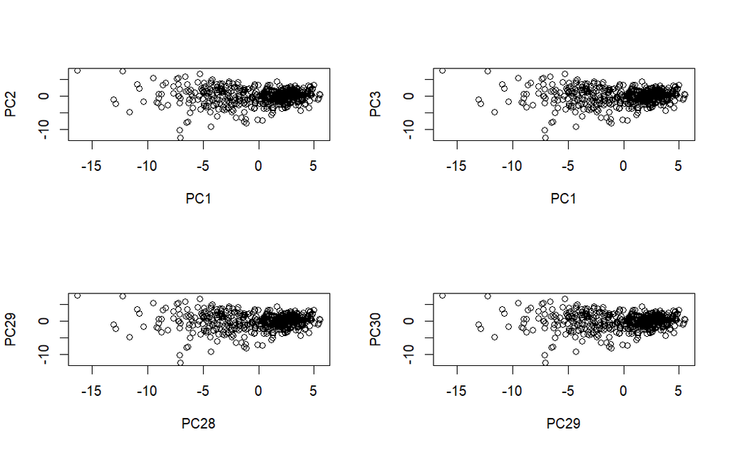

```r
plot(wisc_pca$x[,c(1,2)], xlab= 'PC28', ylab='PC29')
plot(wisc_pca$x[,c(1,2)], xlab= 'PC29', ylab='PC30')
```

#Algoritmo del K-means

## Estudio sobre el parámetro k del K-means (center)

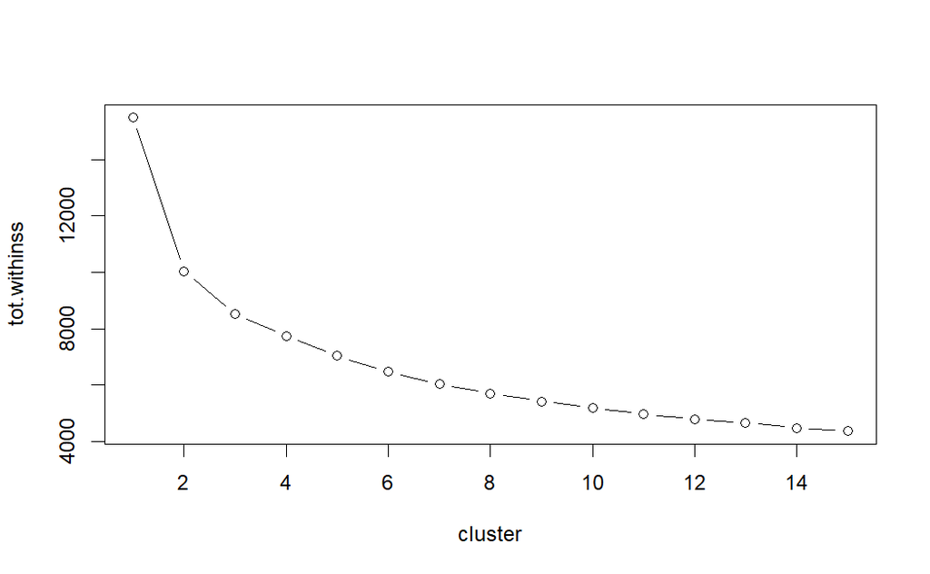

```r
#Ejecuta 15 veces variando el valor de k

vector_compactacion <- 0

for(i in 1:15){
  km_puntos_center <- kmeans(wisc_data_reduccion, center = i, nstart = 20)
  vector_compactacion[i] <- km_puntos_center$tot.withinss
}

#Representa los valores de la compactación

par(mfrow=c(1,1)) #Para quitar la rejilla

plot(1:15, vector_compactacion,
     type = "b",
     xlab = "cluster", ylab="tot.withinss")
```

Los valores de interés podrían ser de 2 a 4. Probemos gráficamente

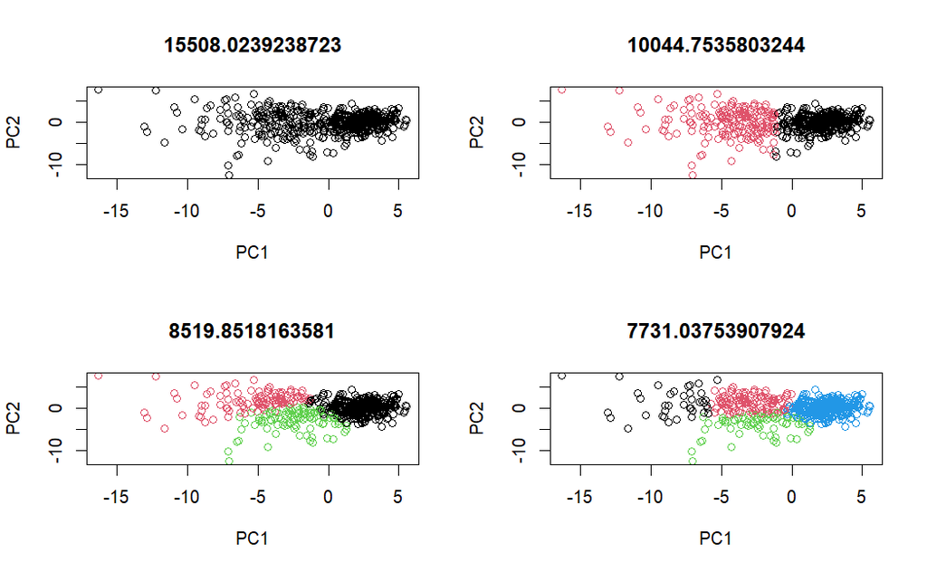

```r
par(mfrow=c(2,2)) #Para mostrar una rejilla de 2x2

for(i in 1:4){
  #nstar=20
  km_wisc_aux <- kmeans(wisc_data_reduccion, center=i, nstart=20)
  plot(wisc_data_reduccion, col=km_wisc_aux$cluster, main=km_wisc_aux$tot.withinss)
}
```

# Clustering jerárquico

```r
#Primero construimos la matriz de distancia entre los puntos
matriz_distancias <- dist(wisc_data_reduccion)

#Ejecutamos el algoritmo
hclust_aux <- hclust(matriz_distancias)

hclust_aux
```

```
Call:
hclust(d = matriz_distancias)

Cluster method   : complete
Distance         : euclidean
Number of objects: 569
```

```r
summary(hclust_aux)
```

```
            Length Class  Mode
merge       1136   -none- numeric
height       568   -none- numeric
order        569   -none- numeric
labels       569   -none- character
method         1   -none- character
call           2   -none- call
dist.method    1   -none- character
```

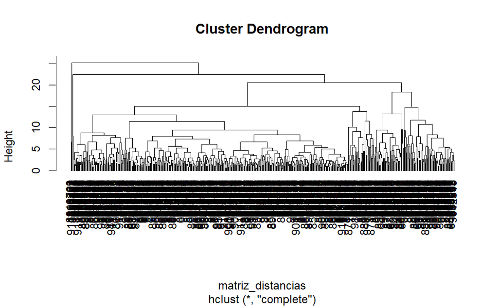

```r
#hclust_aux$ --- Tened en cuenta que esto no es el dendograma, es el resultado del algoritmo

#Representamos el dendograma
plot(hclust_aux, hang=-2)
```

Viendo el dendograma se observa que el k=2 no es muy significativo, será más signficativo k=4. Sin embargo, vamos a comprobarlo pintando el gráfico jerárquico para cada valor de k.

```r
cutree(hclust_aux, k=4)
```

```
   842302    842517  84300903  84348301  84358402    843786    844359  84458202    844981
        1         2         1         1         2         1         2         1         1
 84501001    845636  84610002    846226    846381  84667401  84799002    848406  84862001
        1         2         1         1         2         1         1         2         1
   849014   8510426   8510653   8510824   8511133    851509    852552    852631    852763
        2         2         2         2         1         2         1         1         1
   852781    852973    853201    853401    853612  85382601    854002    854039    854253
        2         1         2         1         1         1         1         1         1
   854268    854941    855133    855138    855167    855563    855625    856106  85638502
        2         2         2         2         2         1         1         2         2
   857010  85713702     85715    857155    857156    857343    857373    857374    857392
        1         2         2         2         2         2         2         2         2
   857438  85759902    857637    857793    857810    858477    858970    858981    858986
        2         2         2         2         2         2         2         2         1
   859196  85922302    859283    859464    859465    859471    859487    859575    859711
```

[output cut: 113 more lines]

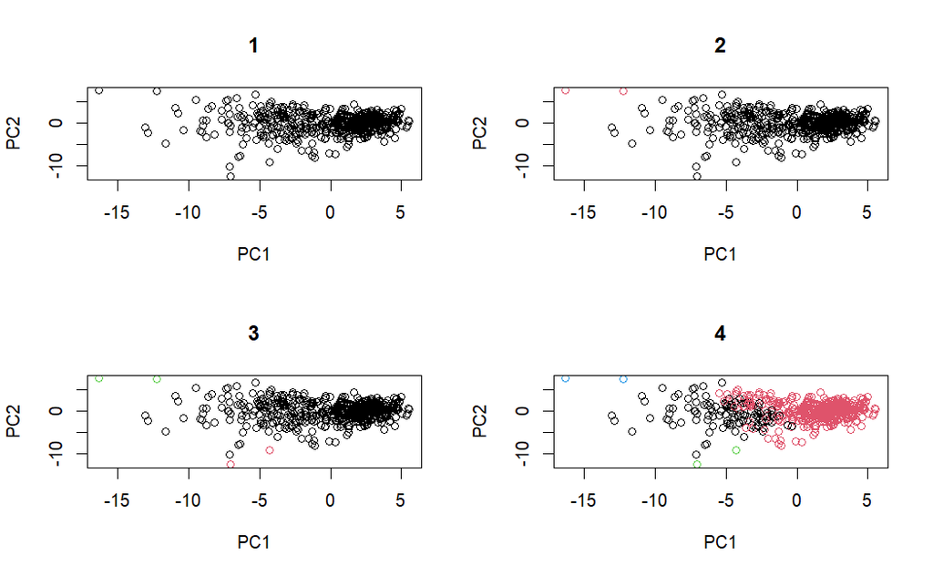

```r
par(mfrow=c(2,2)) #Para mostrar una rejilla de 2x2

for(i in 1:4){
  cut <- cutree(hclust_aux, k=i)
  plot(wisc_data_reduccion,col=cut, main=i)
}
```

Observamos que el único clúster significativo es k=4.